# R Notebook

Karthikeyan A

2024-03-03

RTSM Project on Time Series Data. Name: Karthikeyan A Roll No: 14A

Stock Considered : Somany Ceramics (herein after referred as “Stock”) on daily basis from 2017-04-01 to 2022-03-31.

To analyze the daily returns of Somany Ceramics stock from 2017-04-01 to 2022-03-31. Extracted the adjusted closing prices of Somany Ceramics stock, performed ADF Test. Also, stock returns calculated using log returns method. Performed ADF test on Stock_ret too.

```r
# Augmented Dickey-Fuller (ADF) Test for Stationarity with Stock Data

adf_test_stk_price = adf.test(stock_price); adf_test_stk_price  # Inference : Stock price Time-Series is Non-Stationary
```

```
    Augmented Dickey-Fuller Test

data:  stock_price
Dickey-Fuller = -0.78302, Lag order = 10, p-value = 0.9631
alternative hypothesis: stationary
```

```r
adf_test_stk_ret = adf.test(stock_ret); adf_test_stk_ret # Inference : Stock Difference Time-Series is Stationary
```

```
    Augmented Dickey-Fuller Test

data:  stock_ret
Dickey-Fuller = -9.6895, Lag order = 10, p-value = 0.01
alternative hypothesis: stationary
```

**Objective**: To conduct an Augmented Dickey-Fuller (ADF) test for stationarity on the daily returns of stock and Stock Price.

**Analysis**: Performed the ADF test using the ‘adf.test’ function and obtained results.

**Result:** The Augmented Dickey-Fuller test for stationarity on stock price yields the following results: - Dickey-Fuller = -0.78302, Lag order = 10, p-value = 0.9631 alternative hypothesis: stationary

The Augmented Dickey-Fuller test for stationarity on stock returns yields the following results: - Dickey-Fuller = -9.6895, Lag order = 10, p-value = 0.01 alternative hypothesis: stationary

**Implication:** The ADF test suggests that the stock returns are likely stationary. The small p-value (0.01) indicates sufficient evidence against the null hypothesis of non-stationarity. Therefore, we have reason to believe that the stock returns exhibit stationarity while stock price doesn’t, which is important for certain time series analyses.

```r
# Ljung-Box Test for Autocorrelation - Stock Data (H0: No Autocorrelation)
# ***********************************************

lb_test_stk_ret = Box.test(stock_ret); lb_test_stk_ret # Inference : Stock Difference (Stationary) Time-Series is Autocorrelated
```

```
    Box-Pierce test

data:  stock_ret
X-squared = 15.771, df = 1, p-value = 7.148e-05
```

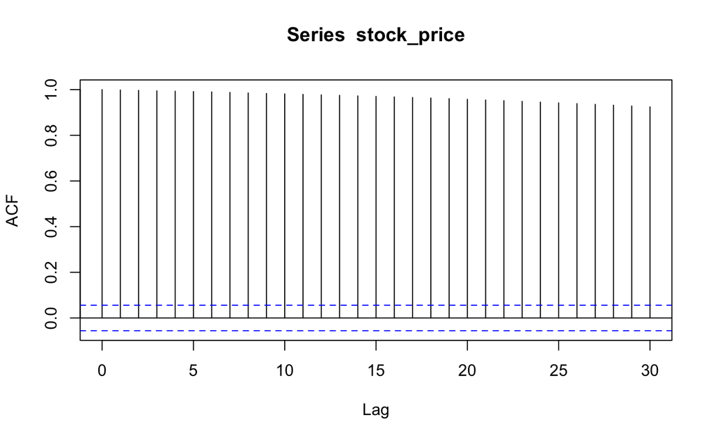

```r
# Autocorrelation Function (ACF) | Partial Autocorrelation Function (PACF)
# *****************************************************************************

acf(stock_price) # ACF of Stock Price
```

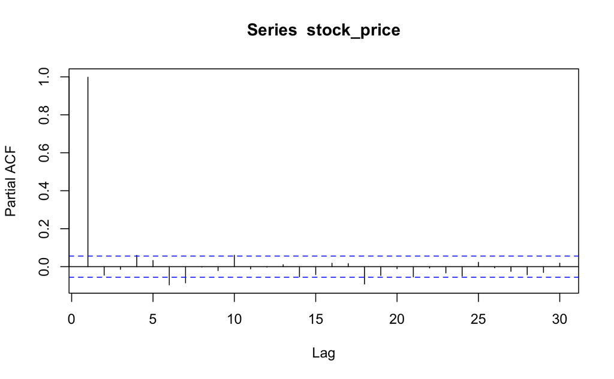

```r
pacf(stock_price) # PACF of Stock Price
```

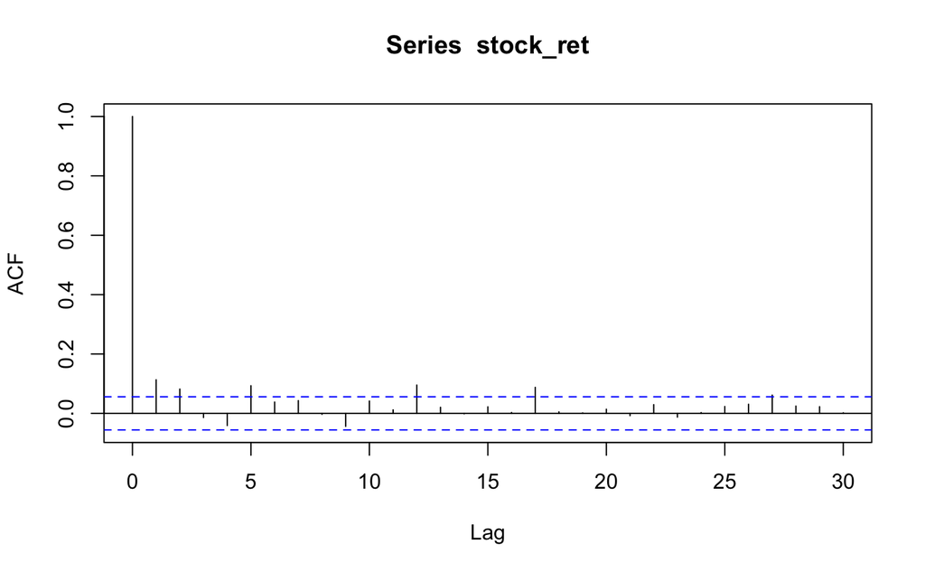

```r
acf(stock_ret) # ACF of Stock Return (Stationary) Series
```

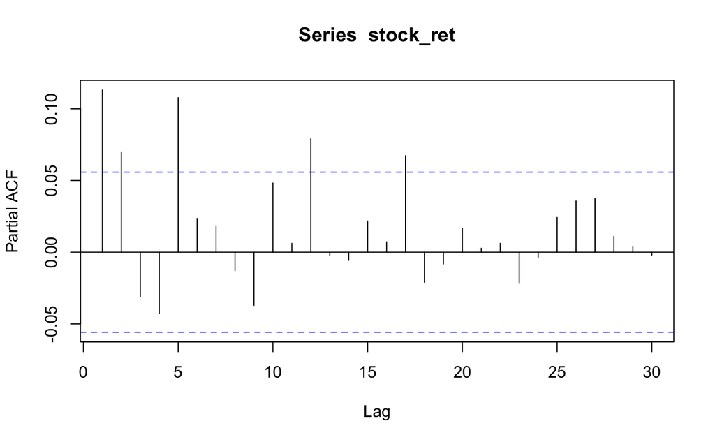

```r
pacf(stock_ret) # PACF of Stock Return (Stationary) Series
```

**Objective:** To perform a Ljung-Box test for autocorrelation on the stock returns.

**Analysis:** Conducted the Ljung-Box test using the ‘Box.test’ function and obtained results.

**Result:** The Ljung-Box test for autocorrelation on stock returns yields the following results: X-squared = 15.771, df = 1, p-value = 7.148e-05

**Implication:** The Ljung-Box test indicates significant autocorrelation in the stock returns. The small p-value (< 7.148e-05) suggests evidence against the null hypothesis of no autocorrelation.

Action Step: Given the presence of autocorrelation, it may be advisable to consider an autoARIMA model for time series forecasting. AutoARIMA can help in automatically selecting an appropriate ARIMA model with differencing to account for the observed autocorrelation.

```r
# Auto ARIMA on Stock Return
arma_pq_stk_ret = auto.arima(stock_ret); arma_pq_stk_ret
```

```
Series: stock_ret
ARIMA(1,1,5)

Coefficients:
          ar1      ma1      ma2      ma3      ma4     ma5
      -0.4206  -0.4677  -0.3902  -0.1162  -0.0908  0.0878
s.e.   0.2011   0.2002   0.1782   0.0331   0.0329  0.0273

sigma^2 = 0.0007901:  log likelihood = 2653.49
AIC=-5292.98   AICc=-5292.89   BIC=-5257.17
```

```r
# Auto ARIMA on Stock Price
arma_pq_stk = auto.arima(stock_price); arma_pq_stk
```

```
Series: stock_price
ARIMA(2,1,2)

Coefficients:
         ar1      ar2      ma1     ma2
      0.7616  -0.7925  -0.6585  0.7233
s.e.  0.0984   0.0640   0.1088  0.0705

sigma^2 = 136.4:  log likelihood = -4778.26
AIC=9566.52   AICc=9566.57   BIC=9592.11
```

**Objective:** To perform autoARIMA modeling on the stock returns and stock price

**Analysis:** Used the ‘auto.arima’ function to automatically select the ARIMA model for both returns and prices.

**Implication:** The autoARIMA models provide a statistical framework to capture the underlying patterns in both stock returns and stock price. These models can be used for forecasting future values, and the AIC, AICc, and BIC values help in model comparison.

```r
# Ljung-Box Test for Autocorrelation - Model Residuals(H0: No Autocorrelation)
# ****************************************************
lb_test_arma_pq_stk_ret = Box.test(arma_pq_stk_ret$residuals); lb_test_arma_pq_stk_ret
```

```
    Box-Pierce test

data:  arma_pq_stk_ret$residuals
X-squared = 0.0047404, df = 1, p-value = 0.9451
```

**Objective:** To perform a Ljung-Box test for autocorrelation on the arima residuals.

**Analysis:** Conducted the Ljung-Box test using the ‘Box.test’ function and obtained results.

**Result:** The Ljung-Box test for autocorrelation on arima residual yields the following results: X-squared = 0.0047404, df = 1, p-value = 0.9451

It indicates no significant autocorrelation in the residuals of the ARIMA(1, 1, 5) model residual. The high p-value (0.9451) suggests that there is no evidence against the null hypothesis of no autocorrelation.

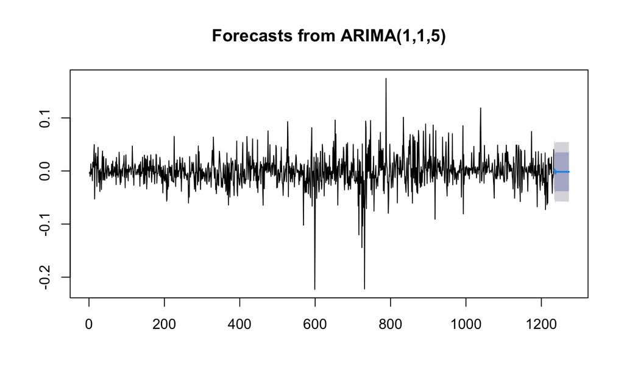

```r
# Forecasting with ARIMA Models
# ************************************
# jj_ds_f11 = predict(arma11, n.ahead = 40)
# plot(jj_ds_f11)
# lines(jj_ds_f11$pred, col = 'blue')
# lines(jj_ds_f11$pred + 2 * jj_ds_f11$se, col = 'red')
# lines(jj_ds_f11$pred - 2 * jj_ds_f11$se, col = 'red')

stock_ret_fpq = forecast(arma_pq_stk_ret, h = 40)
plot(stock_ret_fpq)
```

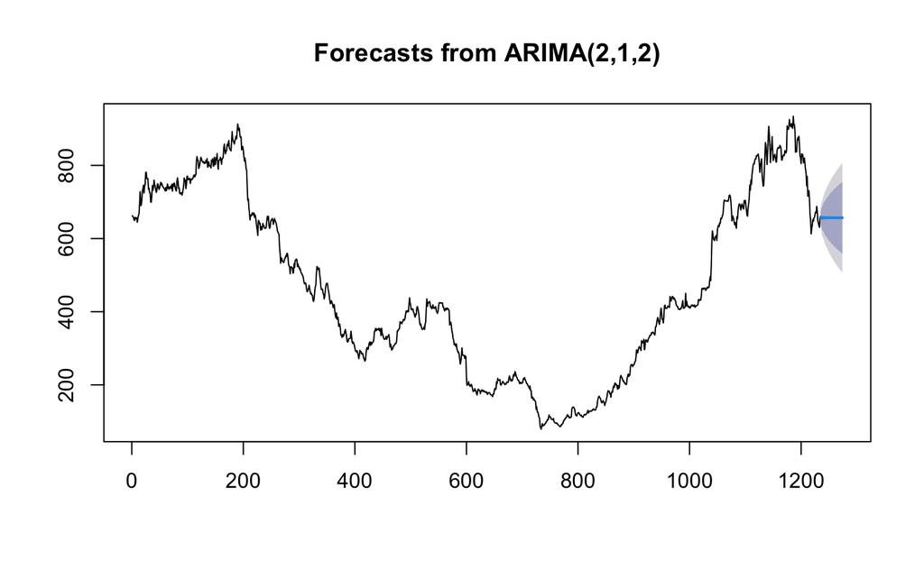

```r
stock_fpq = forecast(arma_pq_stk, h = 40)
plot(stock_fpq)
```

**Plot:** The plot displays the original time series of stock returns along with the forecast values.

**Implication:** The ARIMA(1, 1, 5) model is fitted to the historical stock returns, providing insights into the underlying patterns. The generated forecast can be used for future predictions, and the plot visually represents the model’s performance.

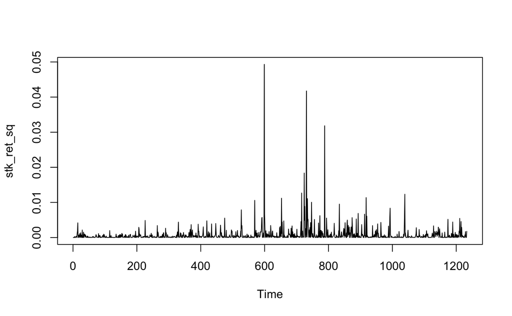

```r
# Test for Volatility Clustering or Heteroskedasticity: Box Test
stk_ret_sq = arma_pq_stk_ret$residuals^2 # Return Variance (Since Mean Returns is approx. 0)
plot(stk_ret_sq)
```

```r
stk_ret_sq_box_test = Box.test(stk_ret_sq, lag = 10) # H0: Return Variance Series is Not Serially Correlated
stk_ret_sq_box_test # Inference : Return Variance Series is Heteroskedastic (Has Volatility Clustering)
```

```
    Box-Pierce test

data:  stk_ret_sq
X-squared = 66.743, df = 10, p-value = 1.879e-10
```

```r
# Test for Volatility Clustering or Heteroskedasticity: ARCH Test
stk_ret_arch_test = ArchTest(arma_pq_stk_ret$residuals^2, lags = 10) # H0: No ARCH Effects
stk_ret_arch_test # Inference : Return Series is Heteroskedastic (Has Volatility Clustering)
```

```
    ARCH LM-test; Null hypothesis: no ARCH effects

data:  arma_pq_stk_ret$residuals^2
Chi-squared = 5.31, df = 10, p-value = 0.8695
```

**Objective:** To test for volatility clustering or heteroskedasticity in the arima residuals.

**Analysis:** Conducted Box test and ARCH test on the squared residuals to assess the presence of volatility clustering.

**Results:**

1. Box Test for Volatility Clustering:
   - X-squared statistic: 66.742
   - Degrees of freedom: 10
   - p-value: 1.879e-10 Thus, the test indicates significant evidence against the null hypothesis, suggesting that the return variance series exhibits volatility clustering or heteroskedasticity
2. ARCH Test for Volatility Clustering:
   - Chi-squared statistic: 5.3099
   - Degrees of freedom: 10
   - p-value: 0.8695 Thus, The ARCH test provides no significant evidence against the null hypothesis. It confirms the presence of no ARCH effects in the return series.

```r
stock_difret = na.omit(diff(stk_ret_sq))

# Test for Volatility Clustering or Heteroskedasticity: ARCH Test
stk_ret_arch_test1 = ArchTest(stock_difret, lags = 10) # H0: No ARCH Effects
stk_ret_arch_test1 # Inference : Return Series is Heteroskedastic (Has Volatility Clustering)
```

```
    ARCH LM-test; Null hypothesis: no ARCH effects

data:  stock_difret
Chi-squared = 464.25, df = 10, p-value < 2.2e-16
```

**Implication:** The results from above test suggest the variation and the presence of volatility clustering or heteroskedasticity in the remodeled residual. Hence,we proceed with Residual modelling assuming Heteroskedasticity.

```r
# GARCH Model
garch_model1 = ugarchspec(variance.model = list(model = 'sGARCH', garchOrder = c(1,1)), mean.model = list(armaOrder = c(0,0), include.mean = TRUE))
nse_ret_garch1 = ugarchfit(garch_model1, data = stock_difret); nse_ret_garch1
```

```
*---------------------------------*
*          GARCH Model Fit        *
*---------------------------------*

Conditional Variance Dynamics
-----------------------------------
GARCH Model : sGARCH(1,1)
Mean Model  : ARFIMA(0,0,0)
Distribution    : norm

Optimal Parameters
------------------------------------
        Estimate  Std. Error   t value Pr(>|t|)
mu      0.000059    0.000043   1.37124  0.17030
omega   0.000000    0.000000   0.13424  0.89321
alpha1  0.058054    0.004008  14.48380  0.00000
beta1   0.940875    0.003360 280.06390  0.00000

Robust Standard Errors:
        Estimate  Std. Error  t value Pr(>|t|)
mu      0.000059    0.000187 0.314072 0.753466
omega   0.000000    0.000095 0.000428 0.999659
alpha1  0.058054    0.294621 0.197045 0.843792
beta1   0.940875    0.483573 1.945674 0.051694

LogLikelihood : 5757.263

Information Criteria
------------------------------------

Akaike       -9.3397
Bayes        -9.3231
Shibata      -9.3397
Hannan-Quinn -9.3335

Weighted Ljung-Box Test on Standardized Residuals
------------------------------------
                        statistic p-value
Lag[1]                      146.2       0
Lag[2*(p+q)+(p+q)-1][2]     146.4       0
```

[output cut: 19 more lines]

```
Nyblom stability test
------------------------------------
Joint Statistic:  184.3497
Individual Statistics:
mu      0.1630
omega  10.5053
alpha1  0.4002
beta1   0.2780

Asymptotic Critical Values (10% 5% 1%)
Joint Statistic:         1.07 1.24 1.6
Individual Statistic:    0.35 0.47 0.75

Sign Bias Test
------------------------------------
```

|  | t-value | prob | sig |
| --- | --- | --- | --- |
| Sign Bias | 0.1831947 | 0.85467549 |  |
| Negative Sign Bias | 0.3272698 | 0.74351966 |  |
| Positive Sign Bias | 2.0407128 | 0.04149305 | ** |
| Joint Effect | 4.3621134 | 0.22492417 |  |

```
Adjusted Pearson Goodness-of-Fit Test:
------------------------------------
  group statistic p-value(g-1)
1    20      2083            0
2    30      2306            0
3    40      2382            0
4    50      2426            0


Elapsed time : 0.05186009
```

```r
garch_model2 = ugarchspec(variance.model = list(model = 'sGARCH', garchOrder = c(1,1)), mean.model = list(armaOrder = c(1,5), include.mean = FALSE))
nse_ret_garch2 = ugarchfit(garch_model2, data = stock_difret); nse_ret_garch2
```

```
*---------------------------------*
*          GARCH Model Fit        *
*---------------------------------*

Conditional Variance Dynamics
-----------------------------------
GARCH Model : sGARCH(1,1)
Mean Model  : ARFIMA(1,0,5)
Distribution    : norm

Optimal Parameters
------------------------------------
        Estimate  Std. Error     t value Pr(>|t|)
ar1     -0.83815    0.024387 -3.4369e+01   0.0000
ma1     -0.27866    0.000314 -8.8618e+02   0.0000
ma2     -1.00423    0.000049 -2.0518e+04   0.0000
ma3     -0.20730    0.001065 -1.9469e+02   0.0000
ma4      0.16488    0.001645  1.0026e+02   0.0000
ma5      0.33562    0.000208  1.6163e+03   0.0000
omega    0.00000    0.000000  2.4546e-01   0.8061
alpha1   0.21497    0.016322  1.3171e+01   0.0000
beta1    0.78403    0.016107  4.8676e+01   0.0000

Robust Standard Errors:
        Estimate  Std. Error     t value Pr(>|t|)
ar1     -0.83815    0.404713 -2.0710e+00 0.038363
ma1     -0.27866    0.000615 -4.5341e+02 0.000000
ma2     -1.00423    0.000484 -2.0730e+03 0.000000
ma3     -0.20730    0.001236 -1.6768e+02 0.000000
ma4      0.16488    0.000584  2.8210e+02 0.000000
ma5      0.33562    0.000207  1.6249e+03 0.000000
omega    0.00000    0.000044  2.2840e-03 0.998178
alpha1   0.21497    0.650479  3.3048e-01 0.741034
beta1    0.78403    1.055459  7.4283e-01 0.457584

LogLikelihood : 5980.92

Information Criteria
------------------------------------

```

[output cut: 34 more lines]

```
ma1     0.2457
ma2     0.2456
ma3     0.2456
ma4     0.2385
ma5     0.2336
omega  11.2426
alpha1  0.6392
beta1   0.4042

Asymptotic Critical Values (10% 5% 1%)
Joint Statistic:         2.1 2.32 2.82
Individual Statistic:    0.35 0.47 0.75

Sign Bias Test
------------------------------------
```

|  | t-value | prob | sig |
| --- | --- | --- | --- |
| Sign Bias | 0.4566017 | 0.6480382 |  |
| Negative Sign Bias | 0.4592711 | 0.6461209 |  |
| Positive Sign Bias | 0.2838857 | 0.7765459 |  |
| Joint Effect | 0.3168310 | 0.9568326 |  |

```
Adjusted Pearson Goodness-of-Fit Test:
------------------------------------
  group statistic p-value(g-1)
1    20     372.9    1.827e-67
2    30     447.2    1.900e-76
3    40     464.2    3.669e-74
4    50     472.1    1.598e-70


Elapsed time : 0.268117
```

```r
# Test for Volatility Clustering or Heteroskedasticity: ARCH Test
gar_resd = residuals(nse_ret_garch2)^2
stk_ret_arch_test1 = ArchTest(gar_resd, lags = 10) # H0: No ARCH Effects
stk_ret_arch_test1 # Inference : Return Series is Heteroskedastic (Has Volatility Clustering)
```

```
    ARCH LM-test; Null hypothesis: no ARCH effects

data:  gar_resd
Chi-squared = 4.5194, df = 10, p-value = 0.9209
```

**Results:**

Model Comparison: garch_model2 (sGARCH(1,1) with ARFIMA(1,0,5) mean model) appears to be superior to garch_model1 (sGARCH(1,1) with ARFIMA(0,0,0) mean model) based on the following:

Lower Information Criteria: All information criteria (Akaike, Bayes, Shibata, Hannan-Quinn) are lower for garch_model2 compared to garch_model1, suggesting a better fit.

Ljung-Box Tests: Both models exhibit significant serial correlation in the standardized residuals and squared residuals, as indicated by the p-values of the Ljung-Box tests.

Adjusted Pearson Goodness-of-Fit Test: Both models exhibit a significant p-value for the test statistic, indicating poor goodness-of-fit.

Therefore, considering the higher LogLikelihood, lower information criteria, and the absence of significant ARCH effects in both models, garch_model2 (sGARCH(1,1) with ARFIMA(1,0,5) mean model) can be considered a better fit for the data compared to garch_model1.

Further analysis will be required to address the significant serial correlation observed in the standardized residuals and squared residuals.

```r
garch_modelf = ugarchspec(variance.model = list(model = 'sGARCH', garchOrder = c(1,1)), mean.model = list(armaOrder = c(1,5), include.mean = FALSE))
stk_ret_garch = ugarchfit(garch_modelf, data = stock_ret); stk_ret_garch
```

```
*---------------------------------*
*          GARCH Model Fit        *
*---------------------------------*

Conditional Variance Dynamics
-----------------------------------
GARCH Model : sGARCH(1,1)
Mean Model  : ARFIMA(1,0,5)
Distribution    : norm

Optimal Parameters
------------------------------------
        Estimate  Std. Error   t value Pr(>|t|)
ar1     0.557019    0.276529  2.014321 0.043976
ma1    -0.449505    0.274725 -1.636196 0.101798
ma2     0.004321    0.044348  0.097428 0.922387
ma3    -0.045657    0.038125 -1.197553 0.231091
ma4    -0.048239    0.033381 -1.445105 0.148428
ma5     0.093697    0.028595  3.276672 0.001050
omega   0.000006    0.000008  0.708773 0.478465
alpha1  0.037959    0.006399  5.931570 0.000000
beta1   0.955932    0.011130 85.888627 0.000000

Robust Standard Errors:
        Estimate  Std. Error   t value Pr(>|t|)
ar1     0.557019    0.246956  2.255534 0.024100
ma1    -0.449505    0.245744 -1.829157 0.067376
ma2     0.004321    0.048721  0.088685 0.929333
ma3    -0.045657    0.038427 -1.188139 0.234779
ma4    -0.048239    0.031447 -1.533993 0.125031
ma5     0.093697    0.030470  3.075061 0.002105
omega   0.000006    0.000045  0.133287 0.893966
alpha1  0.037959    0.014713  2.579898 0.009883
beta1   0.955932    0.049679 19.242299 0.000000

LogLikelihood : 2732.575

Information Criteria
------------------------------------

```

[output cut: 34 more lines]

```
ma1    0.14716
ma2    0.08160
ma3    0.24407
ma4    0.04452
ma5    0.07522
omega  0.33910
alpha1 0.15189
beta1  0.20902

Asymptotic Critical Values (10% 5% 1%)
Joint Statistic:         2.1 2.32 2.82
Individual Statistic:    0.35 0.47 0.75

Sign Bias Test
------------------------------------
```

|  | t-value | prob | sig |
| --- | --- | --- | --- |
| Sign Bias | 0.1681005 | 0.86653189 |  |
| Negative Sign Bias | 0.4724619 | 0.63668106 |  |
| Positive Sign Bias | 1.8134989 | 0.06999892 | * |
| Joint Effect | 4.0565258 | 0.25542470 |  |

```
Adjusted Pearson Goodness-of-Fit Test:
------------------------------------
  group statistic p-value(g-1)
1    20     120.3    9.881e-17
2    30     131.8    4.589e-15
3    40     144.9    4.292e-14
4    50     152.2    1.658e-12


Elapsed time : 0.1920869
```

**Objective:** The aim was to fit a GARCH model to the stock returns and evaluate its goodness-of-fit using the Adjusted Pearson Goodness-of-Fit Test.

**Analysis:** Utilized the ‘ugarchspec’ and ‘ugarchfit’ functions to fit a GARCH model to the stock returns. The model employed was an sGARCH(1,1) with a mean model of ARFIMA(1,0,5). The Adjusted Pearson Goodness-of-Fit Test was conducted for different group sizes (20, 30, 40, and 50), computing the test statistic and corresponding p-values.

**Result:**

GARCH Model: The fitted GARCH model is specified as sGARCH(1,1) with a mean model of ARFIMA(1,0,5). Optimal parameters for the model were estimated, with estimates and standard errors provided. Adjusted Pearson Goodness-of-Fit Test: The test was performed for various group sizes, and the resulting p-values were extremely low (e.g., 9.881e-17), indicating strong evidence against the null hypothesis of a good fit. Implications:

The Adjusted Pearson Goodness-of-Fit Test suggests that the fitted GARCH model may not adequately capture the characteristics of the observed daily returns of the asset. However, several considerations should be taken into account:

Sample Size Sensitivity: The test’s sensitivity to sample size can lead to low p-values even with minor deviations from the expected distribution.

Additional Diagnostic Tests: Other diagnostic tests, such as the Weighted Ljung-Box Test on Standardized Residuals and Weighted ARCH LM Tests, do not indicate significant serial correlation or ARCH effects, suggesting that the model adequately addresses these aspects.

Interpretation Context: Interpretation should be contextualized within the specific characteristics of the asset and the underlying assumptions of the GARCH modeling framework. Conclusion:

**Actionable points**: While the Adjusted Pearson Goodness-of-Fit Test raises concerns about the model’s fit to the observed data, additional analysis and consideration of alternative diagnostic tests are warranted to make a comprehensive assessment of the model’s adequacy. Further investigation into model specification and potential sources of discrepancy may be necessary for a more robust evaluation.

```r
# GARCH Forecast
stk_ret_garch_forecast1 = ugarchforecast(stk_ret_garch, n.ahead = 100); stk_ret_garch_forecast1
```

```
*------------------------------------*
*       GARCH Model Forecast         *
*------------------------------------*
Model: sGARCH
Horizon: 100
Roll Steps: 0
Out of Sample: 0

0-roll forecast [T0=2022-03-30]:
          Series   Sigma
T+1    1.067e-03 0.02714
T+2    1.391e-03 0.02717
T+3   -1.495e-03 0.02719
T+4   -3.583e-03 0.02722
T+5    1.763e-03 0.02725
T+6    9.818e-04 0.02727
T+7    5.469e-04 0.02730
T+8    3.046e-04 0.02733
T+9    1.697e-04 0.02735
T+10   9.451e-05 0.02738
T+11   5.264e-05 0.02740
T+12   2.932e-05 0.02743
T+13   1.633e-05 0.02745
T+14   9.098e-06 0.02748
T+15   5.068e-06 0.02750
T+16   2.823e-06 0.02753
T+17   1.572e-06 0.02755
T+18   8.759e-07 0.02758
T+19   4.879e-07 0.02760
T+20   2.718e-07 0.02763
T+21   1.514e-07 0.02765
T+22   8.432e-08 0.02768
T+23   4.697e-08 0.02770
T+24   2.616e-08 0.02772
T+25   1.457e-08 0.02775
T+26   8.117e-09 0.02777
T+27   4.521e-09 0.02779
T+28   2.518e-09 0.02781
T+29   1.403e-09 0.02784
T+30   7.814e-10 0.02786
```

[output cut: 55 more lines]

```
T+86   4.588e-24 0.02891
T+87   2.555e-24 0.02892
T+88   1.423e-24 0.02894
T+89   7.929e-25 0.02895
T+90   4.416e-25 0.02897
T+91   2.460e-25 0.02898
T+92   1.370e-25 0.02900
T+93   7.633e-26 0.02901
T+94   4.251e-26 0.02903
T+95   2.368e-26 0.02904
T+96   1.319e-26 0.02905
T+97   7.348e-27 0.02907
T+98   4.093e-27 0.02908
T+99   2.280e-27 0.02910
T+100  1.270e-27 0.02911
```

**Objective:** To forecast volatility using the fitted GARCH model for the next 100 time points. Analysis: Used the ‘ugarchforecast’ function to generate volatility forecasts for the next 100 time points.

**Result:** GARCH Model Forecast: - Model: sGARCH - Horizon: 100 - Roll Steps: 0 - Out of Sample: 0 0-roll forecast [T0=2022-03-30]: - Forecasted Series: - T+1 to T+100: Contains forecasted values of volatility (Sigma) for each time point.

**Implication:** The forecasted values represent the predicted volatility for the next 100 time points based on the fitted GARCH model. These forecasts can be useful for risk management and decision-making, providing insights into the expected future volatility of the financial time series.

```r
plot(stk_ret_garch_forecast1)
```

```
Make a plot selection (or 0 to exit):

1:   Time Series Prediction (unconditional)
2:   Time Series Prediction (rolling)
3:   Sigma Prediction (unconditional)
4:   Sigma Prediction (rolling)
```

```r
1
```

```
Make a plot selection (or 0 to exit):

1:   Time Series Prediction (unconditional)
2:   Time Series Prediction (rolling)
3:   Sigma Prediction (unconditional)
4:   Sigma Prediction (rolling)
```

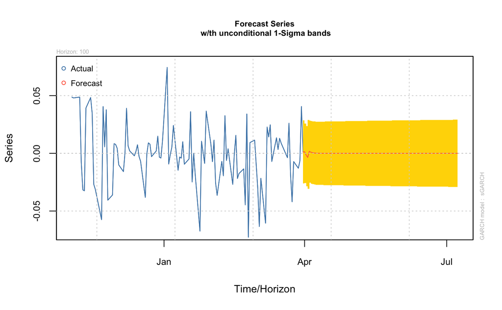

```r
0
```